# Lista04_MQ101_CerveraCelia

Celia Cervera Callacná-21202521058

23/11/2025

# EXERCICIO 1:

```r
set.seed(123)

      # Probabilidade de cara
      p_cara <- 0.3

      # Tamanhos de amostra
      n_vec  <- c(1, 10, 100, 1000, 10000)

      # Data frame para armazenar os resultados
      result <- data.frame(
        n      = n_vec,
        p_cara = NA_real_
      )

      # TODO: completar o loop para simular os lançamentos

      # Bucle para calcular a proporção de caras en cada tamanho
      for (i in seq_along(n_vec)) {

        # Simulamos n_vec[i]lanzamientos de moneda (probabilidade de cara = 0.3)
        x <- rbinom(n = 1, size = n_vec[i], prob = 0.3)

        # Guardamos la proporção de caras
        result$p_cara[i] <- x / n_vec[i]
      }

      # TODO: inspecionar result
      print(result)
```

```
##       n p_cara
## 1     1  0.000
## 2    10  0.400
## 3   100  0.260
## 4  1000  0.309
## 5 10000  0.295
```

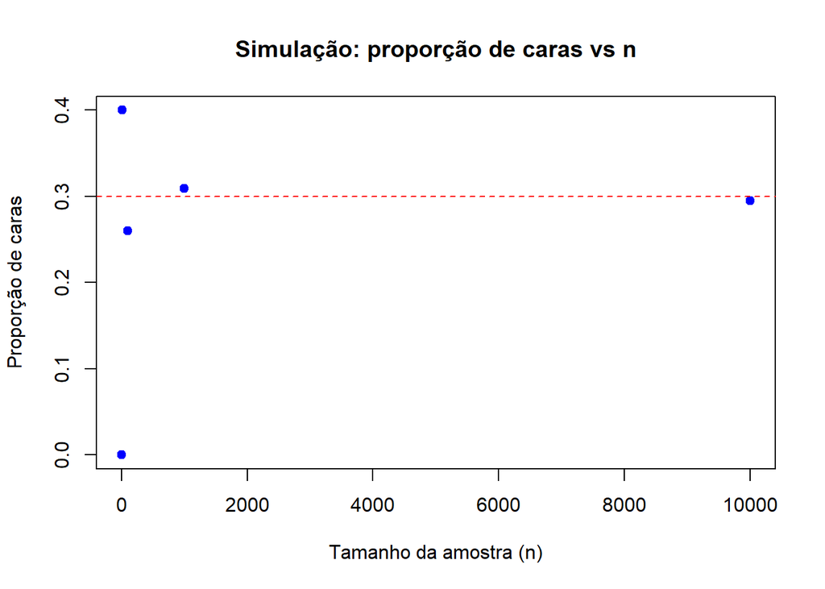

```r
      # TODO: fazer um gráfico de linha da proporção de caras vs n

      plot(result$n, result$p_cara,
           #type = "b",               # pontos e linhas
           pch = 19,                  # com preenchimento
           col = "blue",              # cor
           xlab = "Tamanho da amostra (n)",
           ylab = "Proporção de caras",
           main = "Simulação: proporção de caras vs n")

      abline(h = p_cara, lty = 2, col = "red")  # linha da probabilidade teórica
```

# EXERCICIO 2:

```r
set.seed(123)

      # Parámetros
      p <- 0.65
      n <- 20

      #(1) Simulação de uma amostra
      y <- rbinom(n, size = 1, prob = p)
      print(y)
```

```
##  [1] 1 0 1 0 0 1 1 0 1 1 0 1 0 1 1 0 1 1 1 0
```

```r
      #(2) Contar o número de satisfeitos
      num_satisfeitos <- sum(y)
      print(num_satisfeitos)
```

```
## [1] 12
```

```r
      # (3a) Probabilidade P(S = 12) pela Binomial
      prob_12 <- dbinom(12, size = n, prob = p)

      # (3b) Probabilidade P(S >= 12)
      prob_12_ou_mais <- sum(dbinom(12:n, size = n, prob = p))

      #12:n as possibilidades de serem 12, 13, 14 até 20 os satisfeitos.

      # ou:
      # prob_12_ou_mais <- 1 - pbinom(11, size = n, prob = p)

      # TODO: imprimir os resultados e escrever a interpretação fora do código.
      print(prob_12)
```

```
## [1] 0.161351
```

```r
      print(prob_12_ou_mais)
```

```
## [1] 0.7623776
```

### Interpretação:

[output not shown]

# EXERCICIO 3

```r
set.seed(123)

      N <- 5000

      dados_saude <- data.frame(
        sexo       = sample(c("F", "M"), size = N, replace = TRUE, prob = c(0.55, 0.45)),
        fumante    = rbinom(N, 1, 0.22),
        hipertenso = rbinom(N, 1, 0.30)
      )

      # Estimar as probabilidades
       P_fumante <- mean(dados_saude$fumante == 1) # P(fumante = 1)
       P_fumante_F <- mean(dados_saude$fumante[dados_saude$sexo == "F"] == 1) #P(fumante = 1 | sexo = "F")
       P_fumante_M <- mean(dados_saude$fumante[dados_saude$sexo == "M"] == 1) #P(fumante = 1 | sexo = "M")

      # Gráfico de barras da proporção de fumantes por sexo
      # Dica: usar dplyr + ggplot2

      library(dplyr); library(ggplot2)
      tab_fumo <- dados_saude |>
        dplyr::group_by(sexo) |>
        dplyr::summarise(prop_fumante = mean(fumante))

      print (tab_fumo)
```

```
## # A tibble: 2 × 2
##   sexo  prop_fumante
##   <chr>        <dbl>
## 1 F            0.218
## 2 M            0.203
```

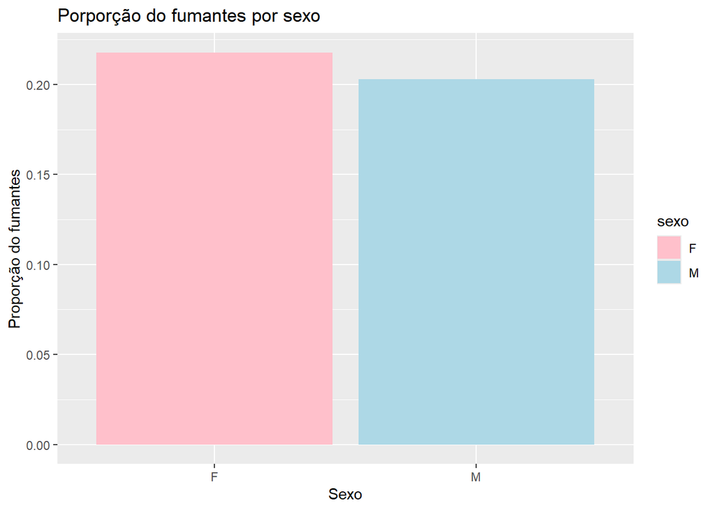

```r
      #Fazer gráfico
      ggplot(tab_fumo, aes(x = sexo, y = prop_fumante, fill=sexo)) +
      geom_col()+
      scale_fill_manual(values = c("F" = "pink", "M" = "lightblue"))+
      labs(x="Sexo", y="Proporção do fumantes",
           title="Porporção do fumantes por sexo")
```

### Interpretação:

Na amostra analisada, a proporção de fumantes é praticamente igual entre homens e mulheres, com uma prevalência ligeiramente maior entre as mulheres (21,8% contra 20,3%). Isso indica que o hábito de fumar não apresenta grandes diferenças por sexo nos dados apresentados.

# EXERCICIO 4 :

```r
# (1) Probabilidades marginais e conjunta
      P_hipertenso <- mean(dados_saude$hipertenso == 1) #P(hipertenso = 1)
      P_fumante    <- mean(dados_saude$fumante == 1) #P(fumante = 1)
      P_hip_e_fum  <- mean(dados_saude$hipertenso == 1 & dados_saude$fumante == 1) #P(hipertenso = 1 & fumante = 1)

      # (2) Probabilidade condicional
      P_hip_dado_fum <- mean(dados_saude$hipertenso[dados_saude$fumante == 1] == 1) #Entre os fumantes, qual é a proporção de hipertensos.

      # (3) Produto: P(hipertenso = 1 | fumante = 1) * P(fumante = 1)
      P_produto <- P_hip_dado_fum * P_fumante

      # TODO: comparar P_hip_e_fum e P_produto, e interpretar.
      print(P_hip_e_fum)
```

```
## [1] 0.0658
```

```r
      print(P_produto)
```

```
## [1] 0.0658
```

A regra do produto funciona como esperado — o cálculo teórico coincide com a proporção observada na amostra.

```r
      print(P_hip_dado_fum)
```

```
## [1] 0.311553
```

```r
      print(P_hip_e_fum)
```

```
## [1] 0.0658
```

### Interprete substantivamente (há evidência de que fumantes têm maior probabilidade de serem hipertensos?)

# EXERCICIO 5:

```r
set.seed(123)

      P_F         <- 0.02
      P_T_dado_F  <- 0.9
      P_T_dado_Fc <- 0.05
      P_Fc        <- 1 - P_F

      # (1) Cálculo analítico de P(F|T)
      P_F_dado_T <- (P_T_dado_F * P_F) /
      (P_T_dado_F * P_F + P_T_dado_Fc * P_Fc)

      # (2) Simulação
      N <- 100000

      fraude <- rbinom(N, 1, P_F) #Sorteo de fraude com prevalencia 0.02
      alerta <- ifelse(           #Generação alerta dado fraude/nao fraude
         fraude == 1,
         rbinom(N, 1, P_T_dado_F), #sensibilidad
         rbinom(N, 1, P_T_dado_Fc) # 1 - especificidad
       )

      #(3) Estimar empiricamente P(F|Alerta)
      P_empirico <- mean(fraude[alerta == 1] == 1)

      # TODO: comparar P_F_dado_T e P_empirico, e interpretar em texto.

      c(
        Empirico   = P_empirico,
        Analitico  = P_F_dado_T,
        Diferencia = P_empirico - P_F_dado_T
      )
```

```
##     Empirico    Analitico   Diferencia
##  0.263799178  0.268656716 -0.004857538
```

### Interpretação:

Os valores são muito prõximos. A maioria dos alertas não corresponde a fraude real.Para cada 100 alertas, apenas aproximadamente 27 são de fato fraude, e aproximadamente 73 são falsos positivos que o algoritmo marcou erroneamente. Isso gera um impacto social, pois na transferência de renda serão detectados falsos positivos para uma questão delicada como a fraude, mas também há um custo operacional, pois cada alerta gera trabalho para verificar se é ou não um erro.

# EXERCICIO 6

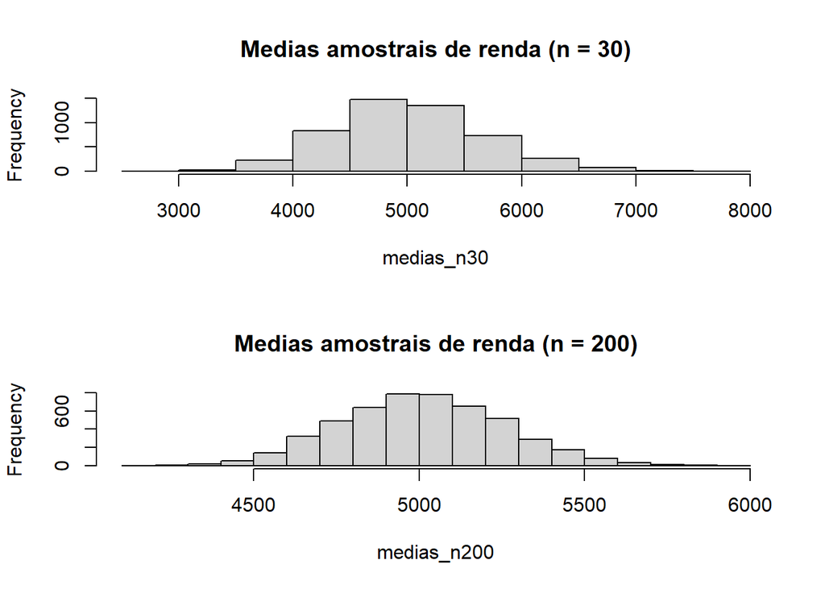

```r
set.seed(123)

      N <- 100000
      renda_pop <- rgamma(N, shape = 2, rate = 1/2500)

      # Função auxiliar para simular médias
      simular_medias <- function(n, n_rep = 5000) {
        medias <- numeric(n_rep)
        for (i in seq_len(n_rep)) {
           amostra <- sample(renda_pop, n, replace = TRUE)
           medias[i] <- mean(amostra)
        }
        medias
      }

      medias_n30  <- simular_medias(30)
      medias_n200 <- simular_medias(200)

      # TODO: produzir histogramas para as distribuições de médias
      par(mfrow = c(2, 1))
      hist(medias_n30,  main = "Medias amostrais de renda (n = 30)")
      hist(medias_n200, main = "Medias amostrais de renda (n = 200)")
```

```r
      par(mfrow = c(1, 1))
```

### Interpretação:

As médias amostrais tendem a seguir uma distribuição normal conforme o tamanho da amostra aumenta.

# EXERCICIO 7:

```r
set.seed(123)

      # Caso nao tenha salvo dados_saude, recriar:
       N <- 5000
       dados_saude <- data.frame(
         sexo       = sample(c("F", "M"), size = N, replace = TRUE, prob = c(0.55, 0.45)),
         fumante    = rbinom(N, 1, 0.22),
         hipertenso = rbinom(N, 1, 0.30)
       )

      n <- 400

      # (1) Amostra aleatoria simples
      amostra_saude <- dados_saude[sample(1:nrow(dados_saude), n), ]

      #seleciona 400 indivíduos aleatoriamente da população

      # (2) Proporcao amostral e IC
       p_hat <- mean(amostra_saude$hipertenso) #proporção de hipertensos na amostra.
       SE_p  <- sqrt(p_hat * (1 - p_hat) / n) #error padrão da proporção.
       IC_95 <- c(
         inferior = p_hat - 1.96 * SE_p,
         superior = p_hat + 1.96 * SE_p
       )

      # (3) Proporção verdadeira na população - 5000 individuos
      p_verdadeiro <- mean(dados_saude$hipertenso)

      # TODO: comparar p_hat, IC_95 e p_verdadeiro em texto.

      print(p_hat)
```

```
## [1] 0.33
```

```r
      print(p_verdadeiro)
```

```
## [1] 0.3014
```

```r
      print (IC_95)
```

```
##  inferior  superior
## 0.2839192 0.3760808
```

A estimativa da amostra está muito próxima do valor real.

# EXERCICIO 8: Correlação, regressão simples e inferência (educação)

```r
set.seed(123)

      N <- 2000

      dados_educacao <- data.frame(
        ideb        = rnorm(N, mean = 5.5, sd = 0.7),   #IDEB:desempenho escolar
        gasto_aluno = rnorm(N, mean = 6000, sd = 1500)
      )

      # Introduzir correlação leve (opcional)
      dados_educacao$ideb <- dados_educacao$ideb +
        0.0002 * (dados_educacao$gasto_aluno - 6000)

      # (2) Correlação de Pearson - availar a relação lineal
      cor_ideb_gasto <- cor(dados_educacao$ideb, dados_educacao$gasto_aluno)
      print(cor_ideb_gasto)
```

```
## [1] 0.3785594
```

```r
      # (3) Regressão simple - como muda o IDEB no função do gasto?
      modelo <- lm(ideb ~ gasto_aluno, data = dados_educacao)
      summary(modelo)
```

```
##
## Call:
## lm(formula = ideb ~ gasto_aluno, data = dados_educacao)
##
## Residuals:
##      Min       1Q   Median       3Q      Max
## -2.14599 -0.46736 -0.00164  0.47298  2.35635
##
## Coefficients:
##              Estimate Std. Error t value Pr(>|t|)
## (Intercept) 4.3573584  0.0652899   66.74   <2e-16 ***
## gasto_aluno 0.0001938  0.0000106   18.28   <2e-16 ***
## ---
## Signif. codes:  0 '***' 0.001 '**' 0.01 '*' 0.05 '.' 0.1 ' ' 1
##
## Residual standard error: 0.7005 on 1998 degrees of freedom
## Multiple R-squared:  0.1433, Adjusted R-squared:  0.1429
## F-statistic: 334.2 on 1 and 1998 DF,  p-value: < 2.2e-16
```

```r
      # Interpretação: Cada R$ 1 000 adicionais do gasto, espera-se um aumento do IDEB em 0.1938

      confint(modelo)
```

```
##                    2.5 %       97.5 %
## (Intercept) 4.2293148316 4.4854018603
## gasto_aluno 0.0001730422 0.0002146291
```

```r
      # Interpretação: O incremento pode ser entre 0.173 e 0.2146 en el IDEB por cada R$ 1 000 adicionais.
```

### Interpretar os coeficientes, valor-p e IC em texto.

A hipotese nula é “Maior gasto x aluno nao tera efeito no ideb. No modelo, o valor-p é muito próximo de 0 (p-value: < 2,2e-16), o que mostra que a relação é estatisticamente significativa. Portanto, rejeita-se a hipotese nula. Há evidência muito forte de que o gasto por aluno está positivamente associado ao desempenho. Apesar disso, o modelo explica apenas cerca de 14% da variação total, indicando que outros fatores afeitam no desempenho dos alunos.

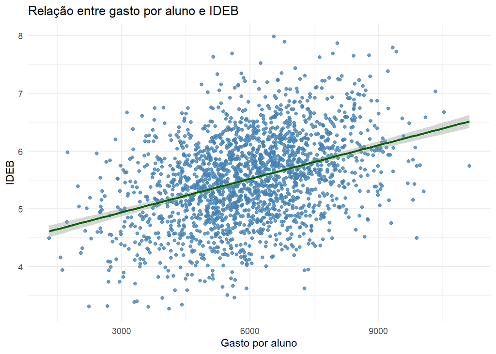

```r
# OPCIONAL:

      ggplot(dados_educacao, aes(x = gasto_aluno, y = ideb)) +
        geom_point(alpha = 0.8, color = "steelblue") +
        geom_smooth(method = "lm", se = TRUE, color = "darkgreen") +
        labs(title = "Relação entre gasto por aluno e IDEB",
             x = "Gasto por aluno",
             y = "IDEB") +
        theme_minimal()
```

# EXERCICIO 9: Margem de erro e tamanho amostral (TSE)

```r
set.seed(123)

      N <- 5000

      dados_tse <- data.frame(
        id_mun       = 1:N,
        prop_partido = rbeta(N, shape1 = 10, shape2 = 15)
      )

      n_amostra <- 600
      n_rep     <- 1000

      # vetor para guardar as proporções amostrais
      p_hat_vec <- numeric(n_rep)

      for (r in 1:n_rep) {
        #(3) sortear um munic??pio
         id_escolhido <- sample(dados_tse$id_mun, 1)
         p_mun <- dados_tse$prop_partido[dados_tse$id_mun == id_escolhido]
        # # sortear 600 eleitores (Bernoulli)
         votos <- rbinom(n_amostra, size = 1, prob = p_mun)
         p_hat_vec[r] <- mean(votos)
      }

      # (4) margem de erro (pior caso)
      ME <- 1.96 * sqrt(0.25 / n_amostra)
      print(ME)
```

```
## [1] 0.04000833
```

```r
    # TODO: fazer um histograma de p_hat_vec e discutir a relação com a margem de erro.
      print(p_hat)
```

```
## [1] 0.33
```

```r
      print(p_hat_vec)
```

[output not shown]

[output cut: 128 more lines]

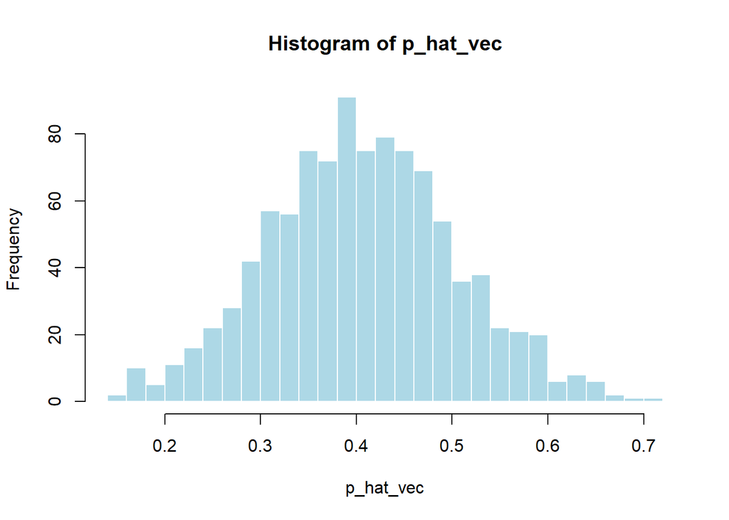

```r
    # Compare essa margem de erro “de praxe” com a variabilidade real observada nas
    # proporções simuladas (por exemplo, com um histograma de p_hat).

      hist(p_hat_vec,
           breaks = 30,
           col = "lightblue",
           border = "white")
```

### Discuta o que isso implica para a interpretação de pesquisas eleitorais.

O margem de erro de 0,04 indica a variabilidade dos dados da amostra respeito os dados da população. Essa margem é útil sempre que a amostra é representativa. Em contextos eleitorais, às vezes é enganosa e otimista, a variabilidade real pode ser maior e depende da representatividade geográfica e demográfica da amostra.

# EXERCICIO 10: Regressão e distribuição amostral do coeficiente (TSE)

```r
set.seed(123)

      N <- 5000

      renda_media <- rnorm(N, mean = 2500, sd = 600)

      prop_partido <- plogis(
        -1 + 0.0006 * renda_media + rnorm(N, 0, 0.3)
      )

      dados_tse <- data.frame(
        id_mun      = 1:N,
        renda_media = rnorm(N, mean = 2500, sd = 600)
      )

      # Probabilidade de apoio ao partido
      dados_tse$prop_partido <- plogis(
        -1 + 0.0006 * dados_tse$renda_media + rnorm(N, 0, 0.3)
      )

      n_mun_amostra <- 300
      n_eleitores   <- 400
      n_rep         <- 500

      coef_angular <- numeric(n_rep)

      for (r in 1:n_rep) {
        # (4) Sortear municípios
         mun_sorteados <- sample(dados_tse$id_mun, n_mun_amostra)
         base_pesq <- dados_tse[dados_tse$id_mun %in% mun_sorteados, ]

        # # Para cada município, simular votos e calcular proporção p_hat
         p_hat <- numeric(n_mun_amostra)

      for (i in seq_len(n_mun_amostra)) {
           p_true <- base_pesq$prop_partido[i]
           votos  <- rbinom(n_eleitores, size = 1, prob = p_true)
           p_hat[i] <- mean(votos)
         }

        base_pesq$p_hat <- p_hat

        # # (5) Ajustar regressão simples
        modelo <- lm(p_hat ~ renda_media, data = base_pesq)
        coef_angular[r] <- coef(modelo)[2]
      }

      median(coef_angular)
```

```
## [1] 0.0001335289
```

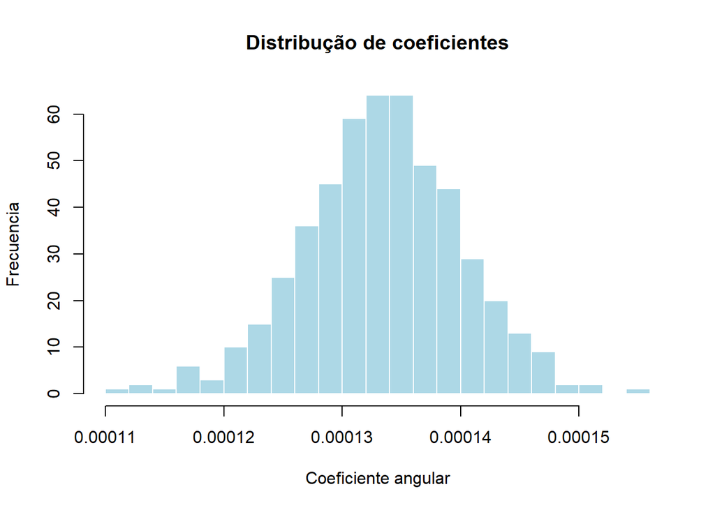

```r
      # TODO: produzir um histograma de coef_angular, e discutir o que representa essa distribuição.

        hist(coef_angular,
           breaks = 30,
           col = "lightblue",
           border = "white",
           main = "Distribução de coeficientes",
           xlab = "Coeficiente angular",
           ylab = "Frecuencia")
```

### Discussão:

O histograma mostra a distribução amostral do estimador da relação entre renda e apoio ao partido, em outras palavras como o coeficiente estimado varia ao longo de reamostragens. Quase não há coeficientes próximos de zero, o que significa que a probabilidade de não existir relação entre as variáveis parece baixa nas réplicas. A média dessa distribuição aproxima o valor verdadeiro do parâmetro. O estimador tem baixa variância: pequenas mudanças na amostra produzem coeficientes semelhantes.